# Discourses of Climate Delay

Discourses of Climate Delay

[William F. Lamb](https://lambwf.github.io/)

# A brief history of Discourses of Climate Delay

2019 was an exciting time for many climate scientists and researchers. The kids were out protesting on the streets and we felt that finally climate change was getting the public attention it deserved. In many ways the conversation on climate change seemed to be changing, no doubt thanks to articulate and plainspoken interventions from Fridays for Future.

It was around this time that myself and a group of friends and colleagues started searching around for new language to describe an emerging form of climate denial. We had observed that many politicians and public commentators - often on the liberal end of the spectrum - would re-assure us during these discussions that they understood the science and impacts of climate change. But then in the same breath they would pour cold water on policies and actions to address it. Inspired by some Twitter conversations, we called this "climate delay" and set out to document the different types and flavours of arguments we had come across.

The result was a commentary that we published in a new open access journal called Global Sustainability. We tried to situate our new concept within an established scholarship on climate denial and obstruction techniques, most famously represented by *The Merchants of Doubt* by Naomi Oreskes and Eric Conway. But at the same time, we wrote this piece for the public, and tried to make it as accessible as possible. That's why we drew a simple graphic to describe the concept, and tried to boil the arguments down to four main categories.

[Discourses of climate delay - the article.](https://www.cambridge.org/core/journals/global-sustainability/article/discourses-of-climate-delay/7B11B722E3E3454BB6212378E32985A7)

To say the response was large is an understatement. Julia Steinberger posted about it on Twitter and the whole thing blew up. We have never seen anything like it. It was particularly surprising to see how the article is used by all kinds of groups, from activisits and communicators, to policy makers and academics. As you can see below, it has inspired art works, a comic book, a quiz and a museum exhibition. On social media it has been turned into bingo cards, has been translated into multiple languages, and adapted for other fields of public policy. Discourses of climate delay is continuously referred to in [news articles and commentaries](https://cambridge.altmetric.com/details/85028937/news) and it remains one of my most highly cited articles in the academic literature.

The social media version of the figure from the paper. Click to see a large version.

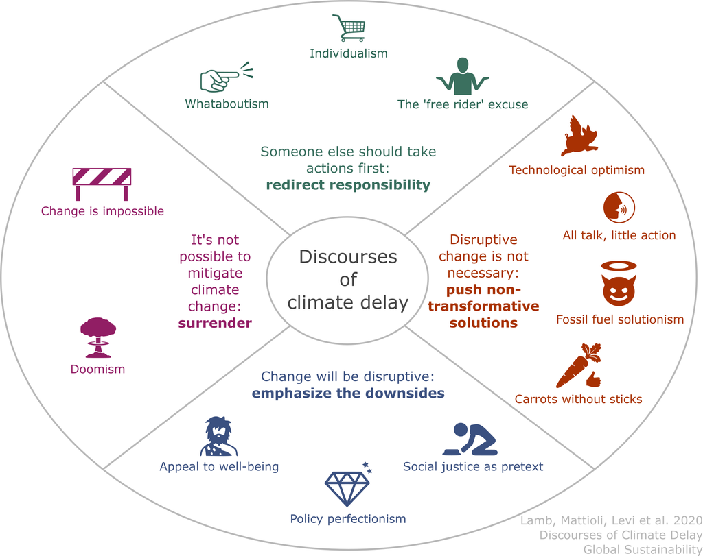

The original figure from the paper. Click to see a large version.

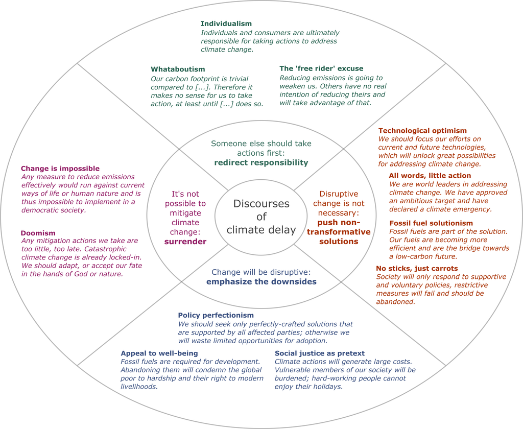

A whole comic book based on the concept by Celine Keller. Click to visit her website and download the book.

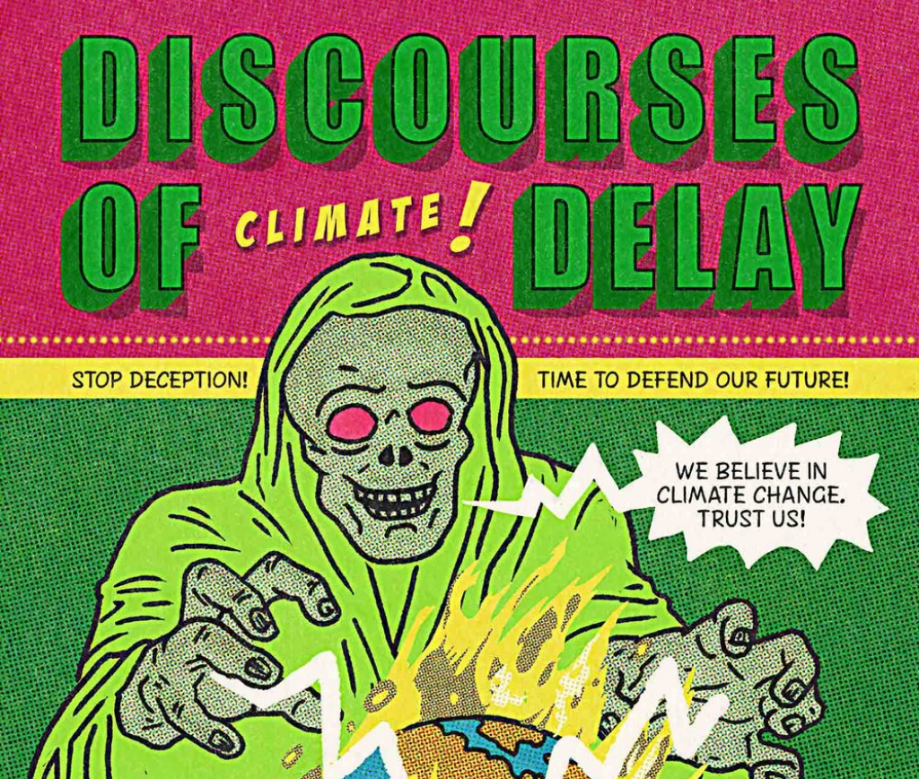

A picture of discourses of climate delay out in the wild, at Berlin’s Museum of Communication! We heard that this exhibit has now moved to Klimahaus Bremerhaven - click to visit their site.

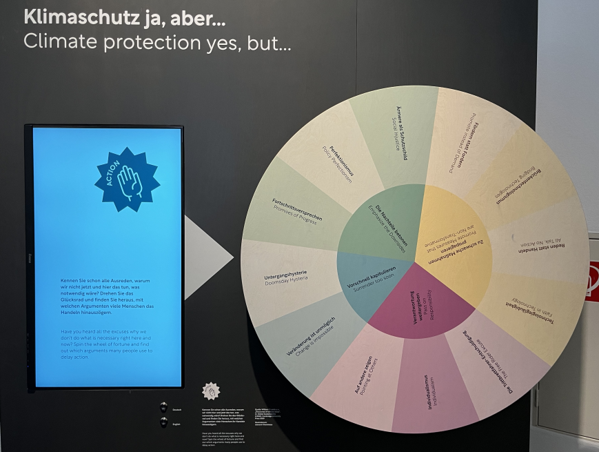

A poster and quiz developed by the German organisation Klimafakten (“Climate Facts”). Click to visit their article (in German).

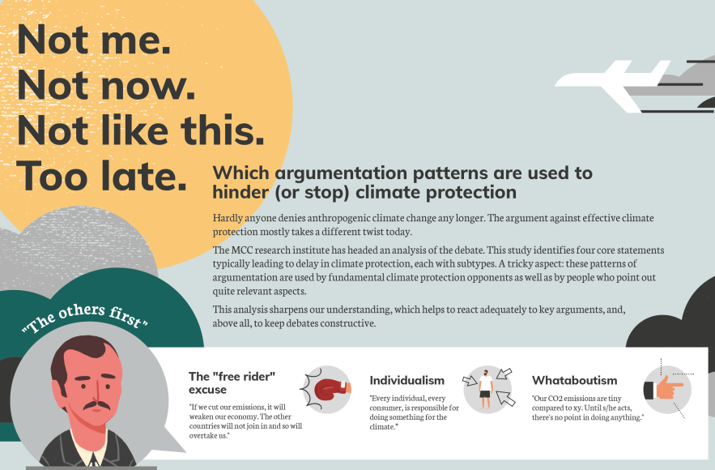

A comic art version of the discourses of climate delay figure by Léonard Chemineau. Click to go to his website and download other versions and languages.

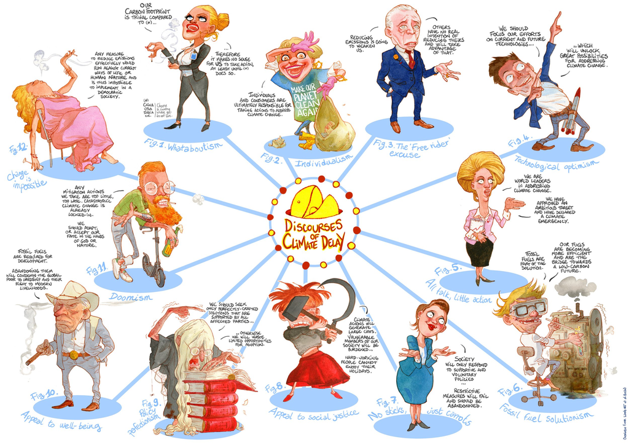

An online version of the exhibit at Frankfurt’s Museum of Communication.

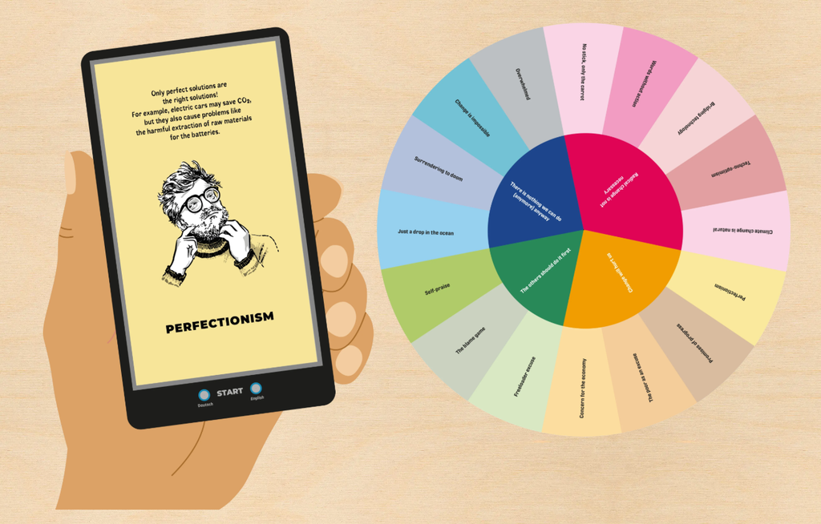

# Translations

This is an incomplete list (please get in touch if you know of more).

- The article in German
- [The main figure in Hungarian](https://bsky.app/profile/dianaurge.bsky.social/post/3lilzl5r4sk2x)
- [English, French, German, Spanish, Italian and Turkish versions of Léonard Chemineau's comic](https://www.leolinne.com/-discourses-of-climate-delay)
- [English, German and Turkish versions of Celine Keller's comic](https://www.celinekeller.com/discourses-of-climate-delay)

# Developments and further work

On reflection, it should be said that our original article does not contain significant empirical research - that's why we published it in the commentary section of the journal! Its therefore nice to see dozens of articles coming out that analyse these discourses in [news media coverage of climate change](https://www.nature.com/articles/s43247-023-00760-2), in [fossil industry messaging](https://www.sciencedirect.com/science/article/pii/S2214629623000889), on [social media](https://link.springer.com/article/10.1007/s10584-023-03494-4), and in [interviews and workshops](https://www.sciencedirect.com/science/article/pii/S2214629623000117?via%3Dihub).

One of the learnings here is that climate delay arguments intersect with all kinds of rhetorical devices, including omissions, distractions, and irrelevancies, but that they also often contain "grains of truth". What I mean is that they can be superficially convincing - aren't some climate policies after all kind of inconvenient? - but only if you somehow forget about the havok the climate change will play on our society and the promise of good solutions that will benefit all of us in the long run.

If you are interested in more work in this area, I can recommend to follow work by [John Cook](https://scholar.google.com/citations?hl=en&user=ZEN_Z2UAAAAJ&view_op=list_works&sortby=pubdate), [Travis Coan](https://scholar.google.com/citations?hl=en&user=Bn1q3fYAAAAJ), [Constantine Boussalis](https://scholar.google.com/citations?user=Cc7R0iIAAAAJ&hl=en) and [Mirjam Nanko](https://scholar.google.com/citations?user=xQznf0kAAAAJ&hl=en). This group published a [piece](https://www.nature.com/articles/s41598-021-01714-4) around the same time as Discourses of Climate Delay with an extensive typology of contrarian claims, including "Climate solutions won't work" (see below). It's a neat organisation of climate delay-type arguments and it sets them in the context of other forms of denial, letting you analyse how claims from different categories trend and interact. They showed that climate delay now supercedes climate denial on right wing think tank blogs, and have trained a [model](https://www.nature.com/articles/s43247-024-01573-7) to automatically classify claims, which they are now applying to many different types of data.

The CARDS taxonomy of climate contrarian claims

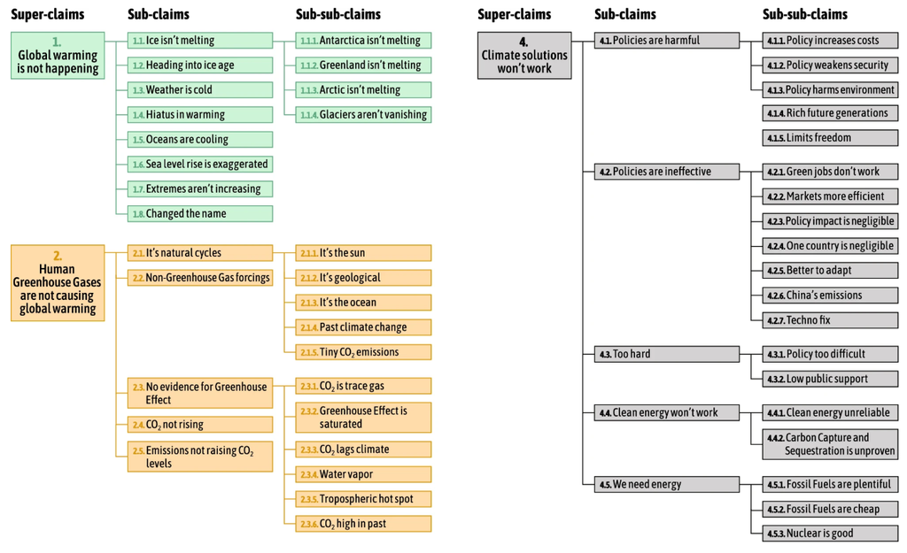

Analysis of contrarian claims on twitter

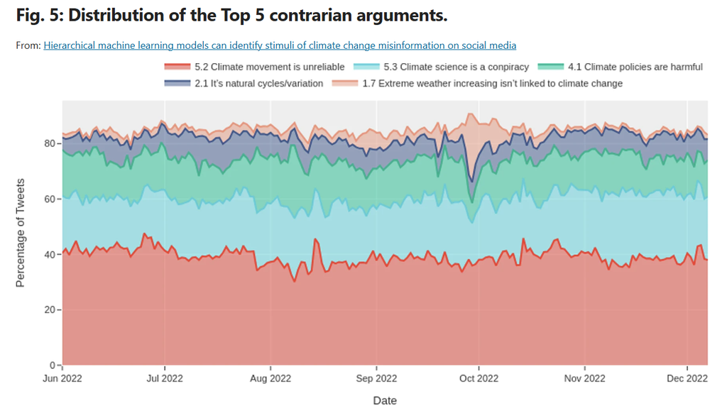

# Critiques

One of the critiques of this piece is that its not always obvious whether someone *intends* to delay climate policy or not. A good example is when social justice aspects of climate policies are discussed. Naturally, we should be able to reflect on and discuss how to make policies more fair and effective. On the other hand, it could be that interest groups aligned with the fossil industry purposefully problematize justice aspects of climate policies, just to discourage us from implementing them.

I think this is a fair critique. Its one of the reasons why we tried to situate our article in the literature on climate obstruction and interest group opposition to climate policy, and not in the literature on public deliberation. Intuitively, we understood that it matters who is propagating climate delay discourses, and in what contexts. The appeal to social justice has a different flavour if it is used by an oil executive, versus a community leader, for example.

Still, the question is how to deal with this issue in practice. The nice thing about Discourses of Climate Delay is that its easy to use as a basic mental framework in everyday life. So it would be great to see research and suggestions on how to evaluate 'intent' and 'context' ([as suggested here](https://www.cambridge.org/core/journals/global-sustainability/article/contextualizing-discourses-of-climate-delay-a-response-to-lamb-et-al-2020/19B61778E8D8DDCE1D18D513D14FA323)), that people can apply in their everyday discussions and interactions around climate change.